# Datos ISTAC Overview

# IPI:

Qué es el IPI

El ïndice de producción Industrial es un índice por lo que tiene bases. (un año de comienzo). La estacionalidad está coorregida

TABLAS EN IPI:

- 2002 - 2018 Base 2015
- 2002 - 2017 Base 2010
- 2002 - 2013 Base 2005

Tabla utilizada: Base 2015 Índices:

- General
- Bienes de Consumo
- Bienes de Consumo Duraderos
- Bienes de Consumo no Duraderos
- Bienes Intermedios
- Bienes de Equipo
- Energía

## Resumen

```r
lapply(list.data_xts, summary)
```

```
$BC_duraderos
     Index                X[[i]]
 Min.   :2002-01-01   Min.   : 44.72
 1st Qu.:2006-02-15   1st Qu.:105.04
 Median :2010-04-01   Median :180.38
 Mean   :2010-04-01   Mean   :215.89
 3rd Qu.:2014-05-16   3rd Qu.:330.11
 Max.   :2018-07-01   Max.   :623.74

$BC_noduraderos
     Index                X[[i]]
 Min.   :2002-01-01   Min.   : 81.13
 1st Qu.:2006-02-15   1st Qu.: 98.43
 Median :2010-04-01   Median :103.39
 Mean   :2010-04-01   Mean   :105.17
 3rd Qu.:2014-05-16   3rd Qu.:111.33
 Max.   :2018-07-01   Max.   :146.85

$bienes_consumo
     Index                X[[i]]
 Min.   :2002-01-01   Min.   : 80.86
 1st Qu.:2006-02-15   1st Qu.: 98.81
 Median :2010-04-01   Median :105.08
 Mean   :2010-04-01   Mean   :107.19
 3rd Qu.:2014-05-16   3rd Qu.:113.48
 Max.   :2018-07-01   Max.   :149.88

$bienes_equipo
     Index                X[[i]]
 Min.   :2002-01-01   Min.   : 69.27
 1st Qu.:2006-02-15   1st Qu.:110.42
 Median :2010-04-01   Median :177.65
 Mean   :2010-04-01   Mean   :209.46
 3rd Qu.:2014-05-16   3rd Qu.:284.79
 Max.   :2018-07-01   Max.   :551.45

$bienes_intermedios
     Index                X[[i]]
 Min.   :2002-01-01   Min.   : 83.34
 1st Qu.:2006-02-15   1st Qu.:100.94
 Median :2010-04-01   Median :144.41
 Mean   :2010-04-01   Mean   :180.94
 3rd Qu.:2014-05-16   3rd Qu.:271.17
 Max.   :2018-07-01   Max.   :337.93

$energía
     Index                X[[i]]
 Min.   :2002-01-01   Min.   : 67.07
 1st Qu.:2006-02-15   1st Qu.: 89.65
 Median :2010-04-01   Median : 96.20
 Mean   :2010-04-01   Mean   : 95.69
 3rd Qu.:2014-05-16   3rd Qu.:102.10
 Max.   :2018-07-01   Max.   :119.00

$general
     Index                X[[i]]
 Min.   :2002-01-01   Min.   : 89.22
 1st Qu.:2006-02-15   1st Qu.:100.47
 Median :2010-04-01   Median :110.51
 Mean   :2010-04-01   Mean   :112.23
 3rd Qu.:2014-05-16   3rd Qu.:122.62
 Max.   :2018-07-01   Max.   :143.22
```

## Primeros Datos

```r
lapply(list.data_xts,head)
```

```
$BC_duraderos
              [,1]
2002-01-01 218.928
2002-02-01 162.819
2002-03-01 196.209
2002-04-01 224.780
2002-05-01 207.913
2002-06-01 190.357

$BC_noduraderos
              [,1]
2002-01-01 112.858
2002-02-01 105.532
2002-03-01 118.810
2002-04-01 118.009
2002-05-01 109.081
2002-06-01 108.966

$bienes_consumo
              [,1]
2002-01-01 113.597
2002-02-01 105.032
2002-03-01 118.593
2002-04-01 118.712
2002-05-01 109.671
2002-06-01 109.077

$bienes_equipo
              [,1]
2002-01-01 378.980
2002-02-01 409.328
2002-03-01 334.569
2002-04-01 405.628
2002-05-01 384.532
2002-06-01 374.909

$bienes_intermedios
              [,1]
2002-01-01 262.638
2002-02-01 254.697
2002-03-01 262.932
2002-04-01 270.873
2002-05-01 272.049
2002-06-01 257.932

$energía
             [,1]
2002-01-01 82.385
2002-02-01 70.767
2002-03-01 87.050
2002-04-01 77.104
2002-05-01 83.617
2002-06-01 88.546

$general
              [,1]
2002-01-01 121.072
2002-02-01 112.442
2002-03-01 123.648
2002-04-01 121.973
2002-05-01 121.587
2002-06-01 122.102
```

## Periocidad y númer de meses

```r
lapply(list.data_xts,periodicity)
lapply(list.data_xts,nmonths)
```

[output not shown]

Voy a poner mis datos como un objeto xts ya que todos tienen los mismo índices

```r
i= 1
IPI<- merge.xts(list.data_xts[[i]],list.data_xts[[i+1]],join = "right")
for (i in 3:length(list.data_xts)){
IPI<- merge.xts(IPI,list.data_xts[[i]],join = "right")
}
#Cambio el nombre de las columnas al original porque merge hace lo que le da la ganacon eso
IPI<-`colnames<-`(IPI,(c(list.filenames)))
head(IPI)
```

```
           BC_duraderos BC_noduraderos bienes_consumo bienes_equipo bienes_intermedios energía general
2002-01-01      218.928        112.858        113.597       378.980            262.638  82.385 121.072
2002-02-01      162.819        105.532        105.032       409.328            254.697  70.767 112.442
2002-03-01      196.209        118.810        118.593       334.569            262.932  87.050 123.648
2002-04-01      224.780        118.009        118.712       405.628            270.873  77.104 121.973
2002-05-01      207.913        109.081        109.671       384.532            272.049  83.617 121.587
2002-06-01      190.357        108.966        109.077       374.909            257.932  88.546 122.102
```

```r
#comprobaciones sobre la nueva xts que acabo de crear con todos los IPI
class(IPI)
```

```
[1] "xts" "zoo"
```

```r
head(IPI)
```

```
           BC_duraderos BC_noduraderos bienes_consumo bienes_equipo bienes_intermedios energía general
2002-01-01      218.928        112.858        113.597       378.980            262.638  82.385 121.072
2002-02-01      162.819        105.532        105.032       409.328            254.697  70.767 112.442
2002-03-01      196.209        118.810        118.593       334.569            262.932  87.050 123.648
2002-04-01      224.780        118.009        118.712       405.628            270.873  77.104 121.973
2002-05-01      207.913        109.081        109.671       384.532            272.049  83.617 121.587
2002-06-01      190.357        108.966        109.077       374.909            257.932  88.546 122.102
```

Plot de datos

[figure not shown]

Datos sin trending

[figure not shown]

# IPRI

Índice de Precios Industriales

Tiene la misma estructura que el IPI

- 2002 - 2018 Base 2015
- 2002 - 2017 Base 2010
- 2002 - 2013 Base 2005

Tabla utilizada: Base 2015 Índices:

- General
- Bienes de Consumo
- Bienes de Consumo Duraderos
- Bienes de Consumo no Duraderos
- Bienes Intermedios
- Bienes de Equipo
- Energía

```r
setwd("~/Documentos/Rstudio/TFM/IPRI_base(2015)")
```

```
The working directory was changed to /home/paula/Documentos/Rstudio/TFM/IPRI_base(2015) inside a notebook chunk. The working directory will be reset when the chunk is finished running. Use the knitr root.dir option in the setup chunk to change the working directory for notebook chunks.
```

```r
# create a loop to read in your data
for (i in 1:length(list.filenames))
{
  list.data[[i]]<-read.csv2(list.filenames[i], header = FALSE, stringsAsFactors = FALSE)
}
```

[output not shown]

## Resumen

```r
lapply(list.data_xts, summary)
```

[output not shown]

## Primeros Datos

```r
lapply(list.data_xts,head)
```

[output not shown]

## Periocidad y númer de meses

```r
lapply(list.data_xts,periodicity)
```

```
$BC_duraderos
Monthly periodicity from 2002-01-01 to 2018-07-01

$BC_noduraderos
Monthly periodicity from 2002-01-01 to 2018-07-01

$bienes_consumo
Monthly periodicity from 2002-01-01 to 2018-07-01

$bienes_equipo
Monthly periodicity from 2002-01-01 to 2018-07-01

$bienes_intermedios
Monthly periodicity from 2002-01-01 to 2018-07-01

$energía
Monthly periodicity from 2002-01-01 to 2018-07-01

$general
Monthly periodicity from 2002-01-01 to 2018-07-01
```

```r
lapply(list.data_xts,nmonths)
```

```
$BC_duraderos
[1] 199

$BC_noduraderos
[1] 199

$bienes_consumo
[1] 199

$bienes_equipo
[1] 199

$bienes_intermedios
[1] 199

$energía
[1] 199

$general
[1] 199
```

Crep una sola tabla xts con todos los datos:

```r
#creo la xts con todo
i= 1
IPRI<- merge.xts(list.data_xts[[i]],list.data_xts[[i+1]],join = "right")
for (i in 3:length(list.data_xts)){
  IPRI<- merge.xts(IPRI,list.data_xts[[i]],join = "right")
}
#Cambio el nombre de las columnas al original porque merge hace lo que le da la ganacon eso
IPRI<-`colnames<-`(IPRI,(c(list.filenames)))
head(IPRI)
```

[output not shown]

```r
#comprobaciones sobre la nueva xts que acabo de crear con todos los IPI
class(IPRI)
```

```
[1] "xts" "zoo"
```

```r
head(IPRI)
```

[output not shown]

Plot de datos

[figure not shown]

Plot de datos sin tendencia:

[figure not shown]

# Encuesta Industrial de Empresa (EIE) ->¡¡¡¡¡¡¡¡¡¡¡¡¡¡¡¡¡¡ESTAS TABLAS SON UN PUTO ROLLO!!!!!!!!!!!!!!!!!!!!!!!!

proporciona información anual de las principales características estructurales de los diversos sectores de la industria en Canarias, permitiendo su comparación con los datos nacionales y de otras comunidades autónomas.

- Series anuales. Comunidades autónomas. 2015-2016. (Metodología 2015/2016):
  - Principales magnitudes estructurales y económicas de la industria según actividades principales (CNAE-2009) en Canarias por años.

    Esta tabla presenta datos del 2015-2016 por sector. Esta tabla es una mierda Intems de encuesta-> sector….
- Series anuales. Canarias. 2008-2014. (CNAE-2009)

  01 Principales agregados contables según agrupaciones de actividad. 02 Principales agregados contables según subagrupaciones de actividad. 03 Personas ocupadas y horas trabajadas según agrupaciones de actividad. 04 Personas ocupadas y horas trabajadas según subagrupaciones de actividad. 05 Procedencia geográfica de las compras según agrupaciones de actividad. 06 Destino geográfico de las ventas según agrupaciones de actividad.

  Macromagnitudes industriales de Canarias

  07 Según agrupaciones de actividad. 08 Según subagrupaciones de actividad.

# Encuesta Industrial Anual de Productos (EIAP)

### Producción por agrupaciones de actividad (CNAE-93)

#### Serie 1993-2000 (millones de pesetas).

```r
remove(datos)
setwd("~/Documentos/Rstudio/TFM/EIAP")
datos<-read_xls('1993_2000.xls',skip = 7)
head(datos)
str(datos)
tail(datos)
summary(datos)


EIAP_1993<-xts_gen2(datos)
head(EIAP_1993)

#summary y plot
summary(EIAP_1993)
```

#### Indicadores

```r
names(EIAP_1993)
```

```
 [1] "TOTAL"
 [2] "Alimentación, bebidas y tabaco. (CNAE: 15-16)"
 [3] "Textil y confección. (CNAE: 17-18)"
 [4] "Cuero y calzado. (CNAE: 19)"
 [5] "Madera y corcho. (CNAE: 20)"
 [6] "Papel, artes gráficas y edición. (CNAE: 21-22)"
 [7] "Coquerías, refino de petróleo y químicas. (CNAE: 23-24)"
 [8] "Manufacturas de corcho y plástico. (CNAE: 25)"
 [9] "Productos minerales no metálicos. (CNAE: 26)"
[10] "Producción, 1ª transformación y fundición de metales. (CNAE: 27)"
[11] "Productos metálicos. (CNAE: 28)"
[12] "Maquinaria y equipo, óptica y similares. (CNAE: 29-30-33)"
[13] "Material eléctrico y electrónico. (CNAE: 31-32)"
[14] "Material de transporte. (CNAE: 34-35)"
[15] "Otras industrias manufactureras. (CNAE: 36)"
```

### Serie 2001-2007 (miles de euros) (datos anuales)!

Faltan datos en estas series:

```r
setwd("~/Documentos/Rstudio/TFM/EIAP")
datos<-read_xls('2001_2007.xls',skip = 7)
head(datos)
str(datos)
tail(datos)
summary(datos)
EIAP_2001<-xts_gen2(datos)
head(EIAP_2001)
summary(EIAP_2001)
```

#### Summary

```r
#summary
summary(EIAP_2001)
```

```
     Index                TOTAL         Alimentación, bebidas y tabaco. (CNAE: 15-16) Textil y confección. (CNAE: 17-18)
 Min.   :2001-01-01   Min.   :3822723   Min.   :1165081                               Min.   : 7905
 1st Qu.:2002-07-02   1st Qu.:4235767   1st Qu.:1279099                               1st Qu.: 8915
 Median :2004-01-01   Median :4543486   Median :1313640                               Median :11853
 Mean   :2004-01-01   Mean   :5037439   Mean   :1311949                               Mean   :11409
 3rd Qu.:2005-07-02   3rd Qu.:5800826   3rd Qu.:1332464                               3rd Qu.:14048
 Max.   :2007-01-01   Max.   :6822677   Max.   :1481793                               Max.   :14324
                                                                                      NA's   :2
 Cuero y calzado. (CNAE: 19) Madera y corcho. (CNAE: 20) Papel, artes gráficas y edición. (CNAE: 21-22)
 Min.   :0                   Min.   :47004               Min.   :229331
 1st Qu.:0                   1st Qu.:49070               1st Qu.:229922
 Median :0                   Median :52111               Median :231468
 Mean   :0                   Mean   :52645               Mean   :239521
 3rd Qu.:0                   3rd Qu.:56641               3rd Qu.:246691
 Max.   :0                   Max.   :57980               Max.   :262623

 Coquerías, refino de petróleo y químicas. (CNAE: 23-24) Manufacturas de corcho y plástico. (CNAE: 25)
 Min.   :1383591                                         Min.   :49479
 1st Qu.:1448794                                         1st Qu.:50522
 Median :1667418                                         Median :53232
 Mean   :1915080                                         Mean   :58652
 3rd Qu.:2417670                                         3rd Qu.:66146
 Max.   :2621627                                         Max.   :74513

 Productos minerales no metálicos. (CNAE: 26) Producción, 1ª transformación y fundición de metales. (CNAE: 27)
 Min.   :510080                               Min.   :16423
 1st Qu.:517195                               1st Qu.:23492
 Median :534143                               Median :28187
 Mean   :576699                               Mean   :27141
 3rd Qu.:614465                               3rd Qu.:31836
 Max.   :729353                               Max.   :35768
                                              NA's   :3
 Productos metálicos. (CNAE: 28) Maquinaria y equipo, óptica y similares. (CNAE: 29-30-33)
 Min.   :133706                  Min.   : 65339
 1st Qu.:155212                  1st Qu.: 75214
 Median :176390                  Median : 95452
 Mean   :189763                  Mean   : 98731
 3rd Qu.:218484                  3rd Qu.:120624
 Max.   :270848                  Max.   :138648

 Material eléctrico y electrónico. (CNAE: 31-32) Material de transporte. (CNAE: 34-35) Otras industrias manufactureras. (CNAE: 36)
 Min.   :13020                                   Min.   :63972                         Min.   :45805
 1st Qu.:13740                                   1st Qu.:64353                         1st Qu.:49132
 Median :18880                                   Median :70406                         Median :52677
 Mean   :18592                                   Mean   :74155                         Mean   :51893
 3rd Qu.:21137                                   3rd Qu.:75637                         3rd Qu.:55438
 Max.   :28488                                   Max.   :96405                         Max.   :56414
                                                 NA's   :2                             NA's   :3
 Energía eléctrica, gas y vapor. (CNAE: 40)
 Min.   :566182
 1st Qu.:566782
 Median :567382
 Mean   :695911
 3rd Qu.:760776
 Max.   :954169
 NA's   :4
```

#### Indicadores

```r
names(EIAP_2001)
```

```
 [1] "TOTAL"
 [2] "Alimentación, bebidas y tabaco. (CNAE: 15-16)"
 [3] "Textil y confección. (CNAE: 17-18)"
 [4] "Cuero y calzado. (CNAE: 19)"
 [5] "Madera y corcho. (CNAE: 20)"
 [6] "Papel, artes gráficas y edición. (CNAE: 21-22)"
 [7] "Coquerías, refino de petróleo y químicas. (CNAE: 23-24)"
 [8] "Manufacturas de corcho y plástico. (CNAE: 25)"
 [9] "Productos minerales no metálicos. (CNAE: 26)"
[10] "Producción, 1ª transformación y fundición de metales. (CNAE: 27)"
[11] "Productos metálicos. (CNAE: 28)"
[12] "Maquinaria y equipo, óptica y similares. (CNAE: 29-30-33)"
[13] "Material eléctrico y electrónico. (CNAE: 31-32)"
[14] "Material de transporte. (CNAE: 34-35)"
[15] "Otras industrias manufactureras. (CNAE: 36)"
[16] "Energía eléctrica, gas y vapor. (CNAE: 40)"
```

## Serie 2008-2017 (miles de euros) (datos anuales)!

```r
remove(datos)
setwd("~/Documentos/Rstudio/TFM/EIAP")
datos<-read_xls('2008_2017.xls',skip = 7, na = "....")
#comprobando
head(datos)
str(datos)
tail(datos)
summary(datos)


EIAP_2008<-xts_gen2(datos)
head(EIAP_2008)

#summary y plot
summary(EIAP_2008)
```

#### Indicadores

```r
names(EIAP_2008)
```

```
 [1] "TOTAL"
 [2] "Alimentación, bebidas y tabaco (CNAE: 10-11-12)"
 [3] "Textil y confección (CNAE: 13-14)"
 [4] "Cuero y calzado (CNAE: 15)"
 [5] "Madera y corcho (CNAE: 16)"
 [6] "Papel, artes gráficas y reproducción de soportes grabados (CNAE: 17-18)"
 [7] "Coquerías, refino, químicas y productos farmacéuticos (CNAE: 19-20-21)"
 [8] "Manufacturas de caucho y plástico (CNAE: 22)"
 [9] "Productos minerales no metálicos (CNAE: 23)"
[10] "Producción, 1ª transformación y fundición de metales (CNAE: 24)"
[11] "Productos metálicos (CNAE: 25)"
[12] "Productos informáticos, electrónicos, ópticos y eléctricos (CNAE: 26-27)"
[13] "Maquinaria y equipo (CNAE: 28)"
[14] "Material de transporte (CNAE: 29-30)"
[15] "Muebles y otras industrias manufactureras (CNAE: 31-32)"
[16] "Reparación e instalación de maquinaria y equipo (CNAE: 33)"
[17] "Producción de energía eléctrica, gas y vapor (CNAE: 35)"
```

# Estadística de producción y consumo de energía eléctrica

Producción bruta, disponibilidad y consumo de energía eléctrica por islas de Canarias y periodos. Series mensuales. Islas. 1991 Enero - 2018 Agosto

*Existen datos para cada Isla. Por ahora solo se verán los datos para Canarias Unidad de Medida MW/h

### OverView de los datos:

```r
setwd("~/Documentos/Rstudio/TFM/Producción_disponibilidad_consumo_energía_eléctricas")
EN<-read_xls('ENERGIA.xls',skip = 7, na = "..", n_max = 333)
#comprobando
head(EN)
str(EN)
tail(EN)
summary(EN)
```

### Limpieza

```r
#limpiando
EN$X__1<-stri_trim(EN$X__1)


#Elimino la primero línea que pone canarias
EN<-EN[-c(1),]
head(EN, n = 10)

#paso las fechas en español a fechas en ingles entedibles por R
EN$X__1<-parse_date(EN$X__1,"%Y %B ",locale=locale("es"))#el primer EN no sale porque tiene una (p) al final... simplemente lo introduzco a mano
class(EN$X__1)

#convierto las cadenas a números
EN[,2:4]<-as.data.frame.numeric(EN[,2,4])
```

### Se convierten a a una matriz Time serie (xts)

```r
#lo convierto en una xts
EN<-(xts(EN[,2:4], order.by = EN$X__1))
class(EN)
head(EN)
tail(EN)
summary(EN)
```

```r
plot.zoo(x = EN[ ,c(names(EN))])
```

[output not shown]

# Recopilación de estadísticas de productos derivados del petróleo

## Series mensuales del precio del petróleo. 1986-2018

```r
summary(precio_gas)
```

```
     Index            Precio del petróleo (barril Brent)
 Min.   :1986-01-01   Min.   :  951
 1st Qu.:1994-03-01   1st Qu.: 1841
 Median :2002-05-01   Median : 2833
 Mean   :2002-05-01   Mean   : 4464
 3rd Qu.:2010-07-01   3rd Qu.: 6496
 Max.   :2018-09-01   Max.   :13284
```

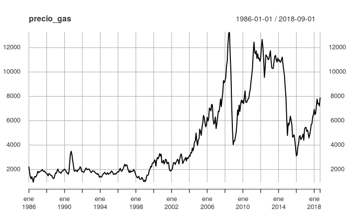

## Series mensuales de consumos. Provincias de Canarias. 2003-2018

Datos para Las Palmas, Santa Cruz, y Canarias Datos para Galosina(95, 97 y 98) Gasoleo (A, B yC) y Fuelóleo Unidad de medida: Tonelada Tipo de dato: Flujo

```r
summary(consumo_gas)
```

```
     Index               FUELÓLEO         GASÓLEO         GASOLINA
 Min.   :2003-01-01   Min.   :  3468   Min.   :45680   Min.   :35561
 1st Qu.:2006-11-16   1st Qu.: 55116   1st Qu.:57259   1st Qu.:41236
 Median :2010-10-01   Median : 94769   Median :69848   Median :43699
 Mean   :2010-10-01   Mean   : 79817   Mean   :67364   Mean   :44489
 3rd Qu.:2014-08-16   3rd Qu.:110229   3rd Qu.:74994   3rd Qu.:48233
 Max.   :2018-07-01   Max.   :140673   Max.   :98643   Max.   :67671
```

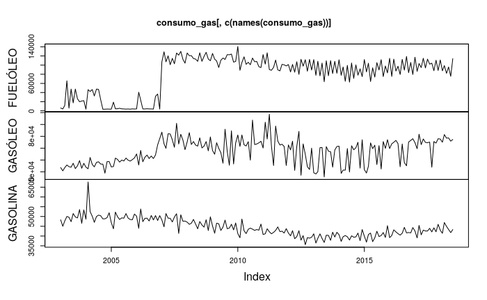